# ggplot

Start off by reading this paper on the motivations and structure behind the ggplot library. It should give you an excellent background for how to think about a `ggplot` object, as well as introductions into common terms.

## A Layered Grammar

I love this paper, and the `ggplot2` package, because it presents a very different philosophy of data visualization than many of us think about. We’re trained to think about graphics as “scatter plots”, or “bar charts”, or “coxcomb diagrams”, when in reality what we’re seeing is a set of *shapes* that *correspond to* some *data*, overlaid on top of a common *scheme for understanding that data*. A plot is, very literally, nothing but shapes stacked on top of each other, and thinking about them in that way allows you an immense amount of freedom in how you design them. `ggplot` strikes an excellent balance between allowing you the freedom to do whatever you like with your visualizations and providing you with excellent defaults if you don’t want to get too far into the weeds.

Now that you know some theory, let’s put it into practice! This page is designed to give you some basics of plotting in `ggplot2`. Whenever you print a plot, it will show up in the `Plots` tab in the panel to the bottom right of your RStudio session.

A quick note about terminology: Wickham described `ggplot` as “a layered grammar”, but to avoid confusion I think “modular” might be a better term. As you’ll notice when we’re constructing a plot below, “layer” actually has a specific meaning in `ggplot`: it’s an instance of a single `geom` function (that is, something that actually draws data onto the screen in the form of some shape). The other plot components, like labels and faceting and coordinates, are *added on* in the same way `geoms` are, but they are *not* referred to as “layers”. For clarity, I’ll refer to any modularized plot component as a “component”, and only to layers specifically as “layers”.

`ggplot` functions are unlike anything else you’ll see in R, because they work by *adding* functions to each other. You literally stack things on top of each other, using the `+` sign to add a new component. Get used to this grammar!

## Plotting Salaries

### Loading Libraries and Data

As always, we need to start by loading libraries: in this case we want `car` to load our data, `data.table` to wrangle it, and `ggplot2` to plot it. What would we do to load those libraries, load the “Salaries” dataset, and convert that dataset to a `data.table`? Hopefully, you remember:

```r
library(car)
library(data.table)
library(ggplot2)

data(Salaries)
Salaries <- data.table(Salaries)
```

Say we want to make a scatterplot, with `yrs.since.phd` on the x-axis and `salary` on the y-axis. Let’s walk through this, piece by piece.

### Bare `ggplot`

Every `ggplot` command will begin with the function `ggplot()`. This will create an object of type `ggplot`, to which you can then add the rest of your plot components. Let’s start by making a completely empty `ggplot` object:

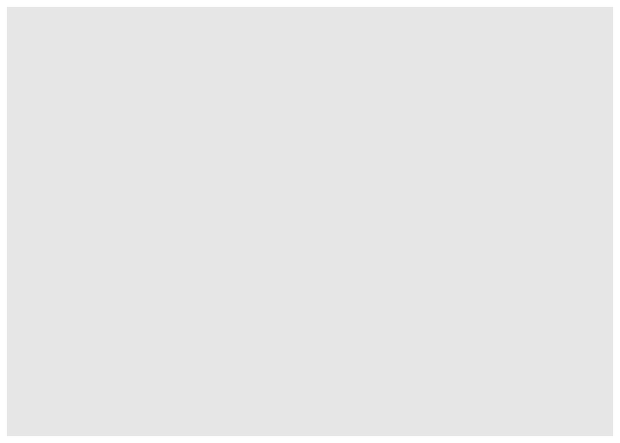

```r
base_plot <- ggplot()
print(base_plot)
```

This is… nothing. Just a grey background. But you’ll notice that we’ve now created an object called `base_plot`, of type `ggplot`, that has some properties:

```r
class(base_plot) # what type of object is this?
```

```
## [1] "gg"     "ggplot"
```

```r
base_plot$layers # No layers so far, just an empty list
```

```
## list()
```

```r
base_plot$data # No data associated with it
```

```
## list()
## attr(,"class")
## [1] "waiver"
```

```r
base_plot$mapping # Nothing is "mapped" onto this dataset yet
```

```
## * NULL ->
```

#### Data

Our first step should be to associate some data with this plot– `data` is the first argument to `ggplot()`:

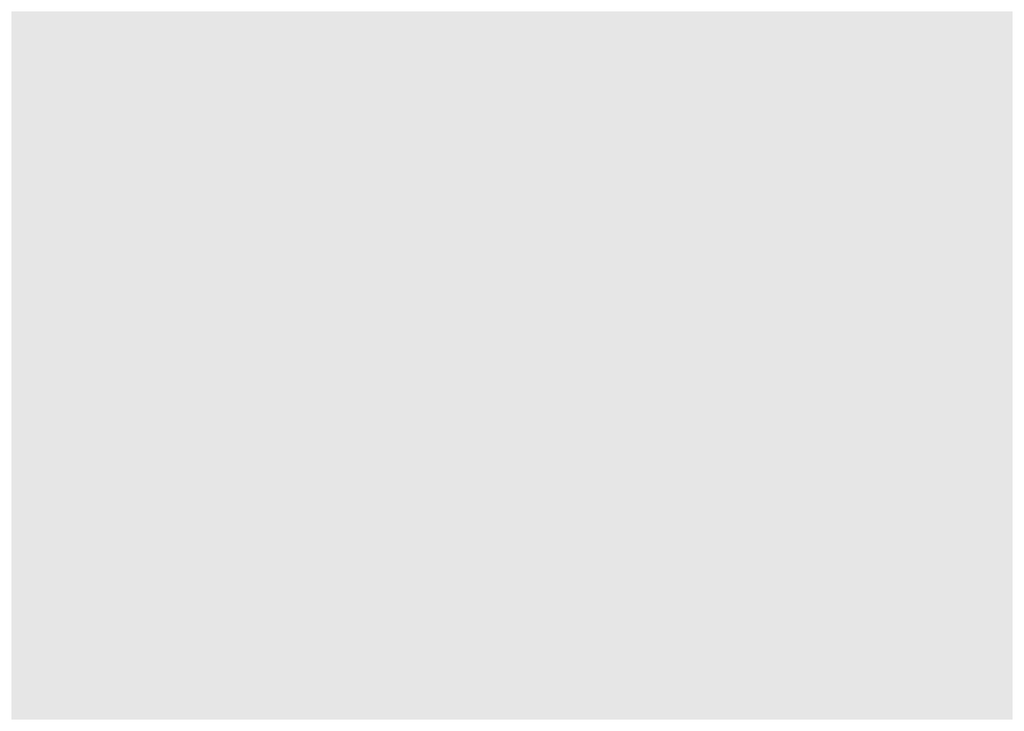

```r
base_plot <- ggplot(data=Salaries)
print(base_plot)
```

Still no change to what we see, but look at `base_plot`’s `data` attribute now:

```r
base_plot$data
```

```
##          rank discipline yrs.since.phd yrs.service  sex salary
##   1:     Prof          B            19          18 Male 139750
##   2:     Prof          B            20          16 Male 173200
##   3: AsstProf          B             4           3 Male  79750
##   4:     Prof          B            45          39 Male 115000
##   5:     Prof          B            40          41 Male 141500
##  ---
## 393:     Prof          A            33          30 Male 103106
## 394:     Prof          A            31          19 Male 150564
## 395:     Prof          A            42          25 Male 101738
## 396:     Prof          A            25          15 Male  95329
## 397: AsstProf          A             8           4 Male  81035
```

There’s data there now! We just need to tell `ggplot` what to do with it!

#### Mappings

We use the sub-function `aes()` to create **mappings** within `ggplot`. (“aes” stands for “aesthetic”.) Any time you want to take the *values of a column* in your dataset and *represent them on your plot* somehow, that’s called a *mapping*, or an *aesthetic*. In this case, we said that we want to map `yrs.since.phd` to the *x-axis position*, and `salary` to the *y-axis position*. So, we include an `aes` function as an argument in our `ggplot` function:

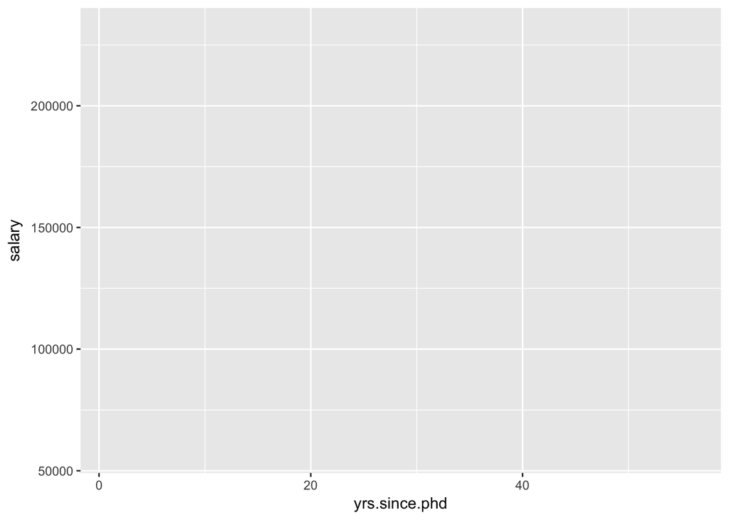

```r
base_plot <- ggplot(data=Salaries, aes(x=yrs.since.phd, y=salary))
print(base_plot)
```

Now we’re getting somewhere! We’ve imposed a range to the axes, which comes with some default labeling and grid lines. Our `base_plot$data` attribute still looks the same, and now we also have a couple of *mappings*:

```r
base_plot$mapping
```

```
## * x -> yrs.since.phd
## * y -> salary
```

### Layer 1: Points

We’ve said that we want a scatterplot, but where’s the “scatter”? Well, up to this point we haven’t told `ggplot` *how* we want to represent our data, so it hasn’t drawn anything. We need to use one of our many **geoms** to describe how we want to draw the data on the page. For a scatterplot, we use a function called `geom_point()`. This is a new plot component, so it gets added on top of our `ggplot` function with a `+` sign:

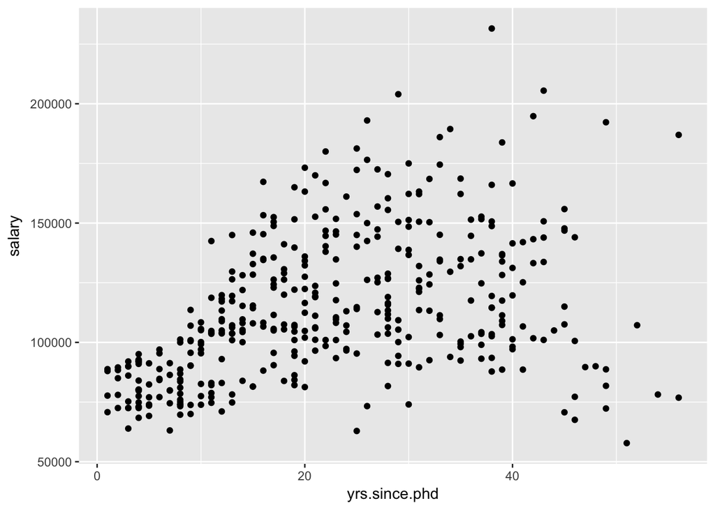

```r
layer_1 <- ggplot(data=Salaries, aes(x=yrs.since.phd, y=salary)) +
          geom_point()
print(layer_1)
```

Hey-o! That looks like a real plot! Let’s see what the `layers` look like on this one:

```r
layer_1$layers
```

```
## [[1]]
## geom_point: na.rm = FALSE
## stat_identity: na.rm = FALSE
## position_identity
```

These are some details for a `geom_point` layer.

### A New Mapping: Color

What if we wanted each of these points to be a different color, based on the rank of each professor? Well, we have a column named `rank`, and we want to *map* it to color, so we need to put it in an `aes()` function:

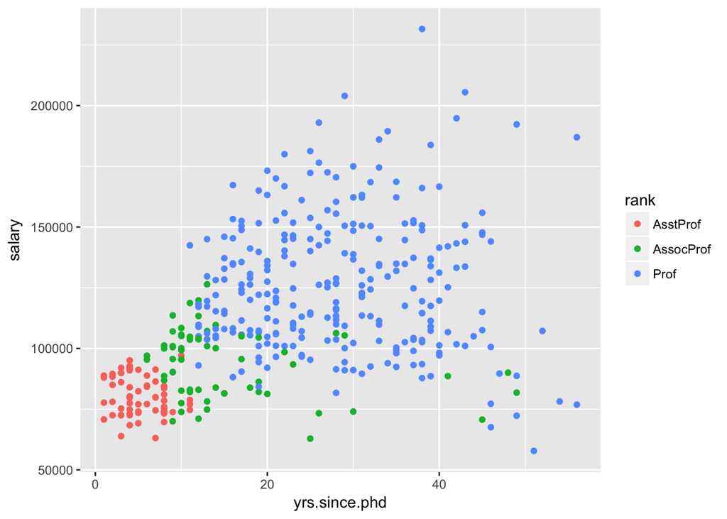

```r
layer_1 <- ggplot(data=Salaries, aes(x=yrs.since.phd, y=salary, color=rank)) +
          geom_point()
print(layer_1)
```

I personally prefer to associate colors with specific layers, so I would actually do something like this:

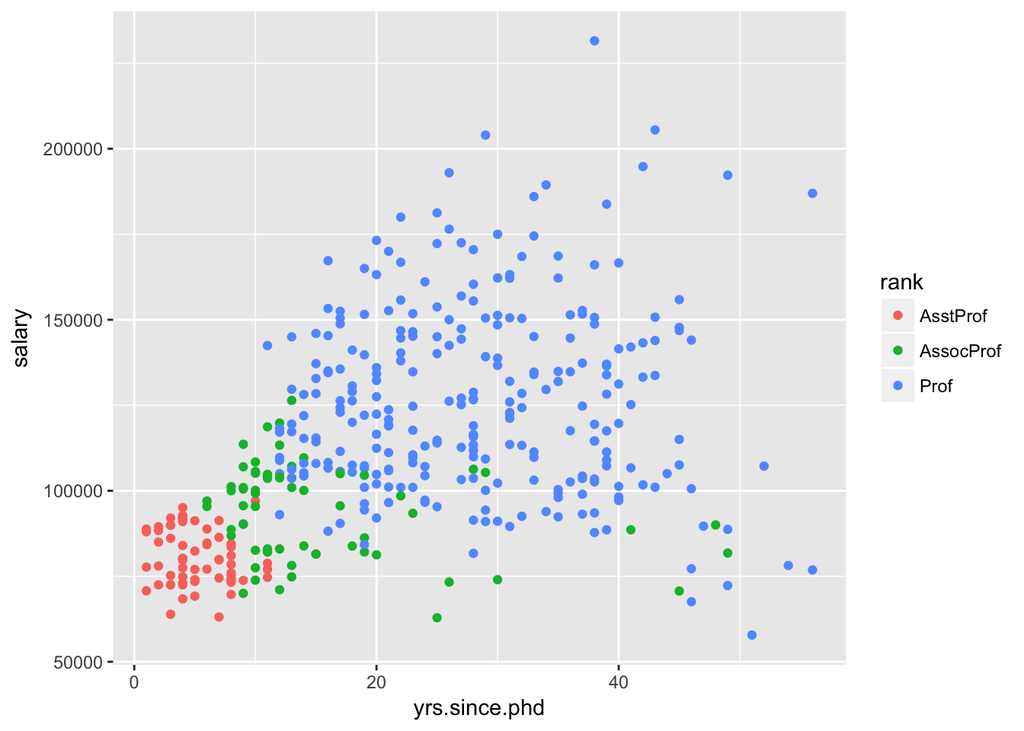

```r
layer_1 <- ggplot(data=Salaries, aes(x=yrs.since.phd, y=salary)) +
          # notice how I associate this mapping with the *layer*, not the plot as a whole
          geom_point(aes(color=rank))
print(layer_1)
```

### Layer 2: Best-Fit Lines

Ok, so now I’ve made this nice scatterplot, and the general trend seems to be that more years since Ph.D corresponds to a higher salary. I’d like to verify this by putting one of those nice “best-fit lines”[^1] through my data. There are rigorous ways to do this that we’ll get to shortly, but a nice shortcut is a function called `geom_smooth()`. By default, `geom_smooth` will fit a curve called a `loess` to the data, so if we want to fit a straight line, we need to pass it the `method` argument `"lm"`, for “linear model”:

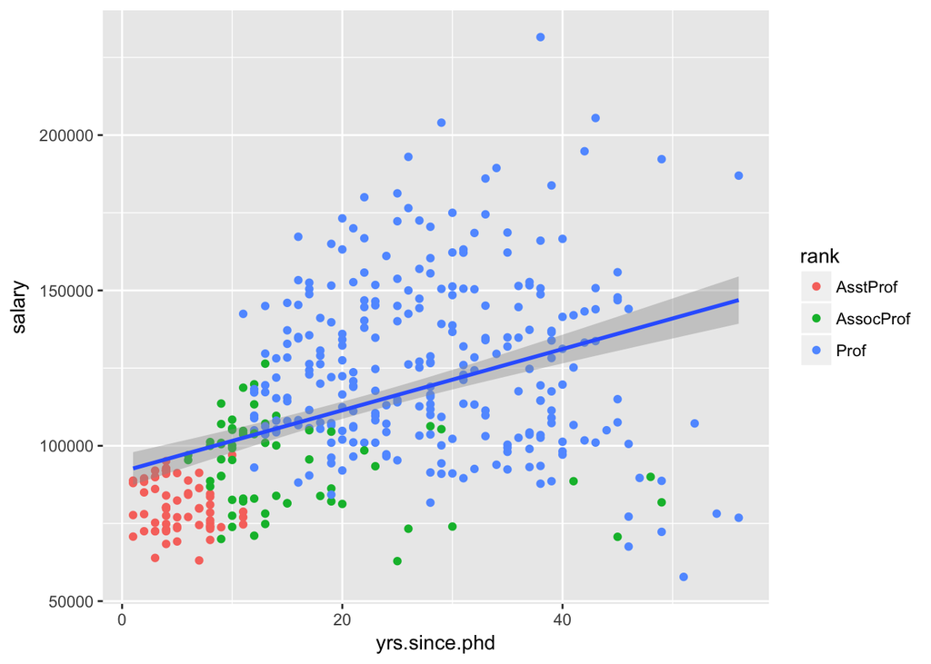

```r
layer_2 <- ggplot(data=Salaries, aes(x=yrs.since.phd, y=salary)) +
          geom_point(aes(color=rank)) +
          geom_smooth(method="lm")
print(layer_2)
```

If you do `layer_2$layers`, you’ll see that we’ve added a second layer to our `ggplot` object, for our best-fit line.

I don’t love that this line is blue– it interferes with the blue of the points behind it. I want to change it to black. Should this be inside an `aes()` function, or not?

Hopefully, you said “no”– I’m not trying to *map* any column of my dataset to the color of the line, I just want to change the color of the line. I can do that directly inside my `geom_smooth` function, no `aes()` needed:

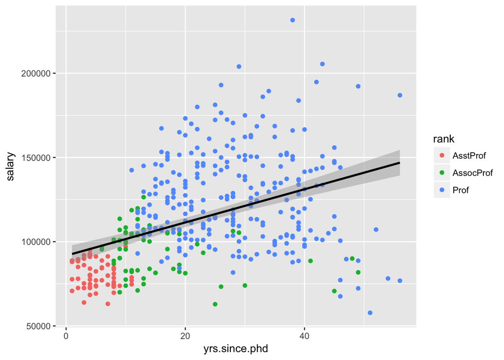

```r
layer_2 <- ggplot(data=Salaries, aes(x=yrs.since.phd, y=salary)) +
          geom_point(aes(color=rank)) +
          # notice the *absence* of an aes() function below
          geom_smooth(method="lm", color="black")
print(layer_2)
```

### Faceting

Remember faceting? It’s another term for making subplots by splitting your dataset based on some column in the dataset. So, for example, if I wanted to split my data by `sex`, and make a subplot for each, I would do:

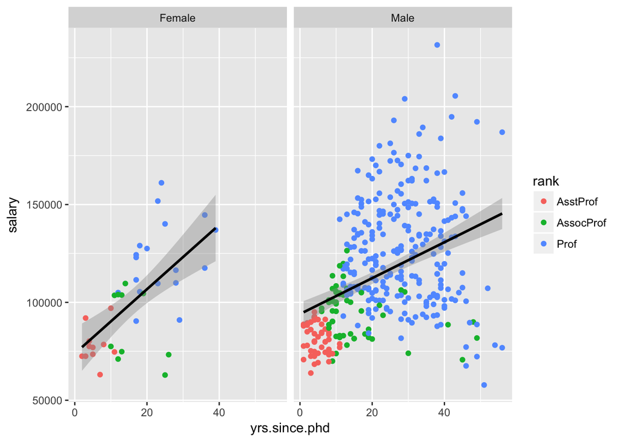

```r
faceting <- ggplot(data=Salaries, aes(x=yrs.since.phd, y=salary)) +
          geom_point(aes(color=rank)) +
          geom_smooth(method="lm", color="black") +
          # adding a facet_wrap component
          facet_wrap(~sex)
print(faceting)
```

Notice the format of the argument to `facet_wrap`– does it look familiar? It’s a `formula` object, just like what we used for reshaping last lecture, except that there’s nothing on the left side of the `~`.

You can also facet in *two different directions*, using the `facet_grid` function. This is where the fact that the argument is a formula starts to make sense: the subplots are split into “rows”" by whatever is to the left of the `~`, and into columns by whatever is to the right of it:

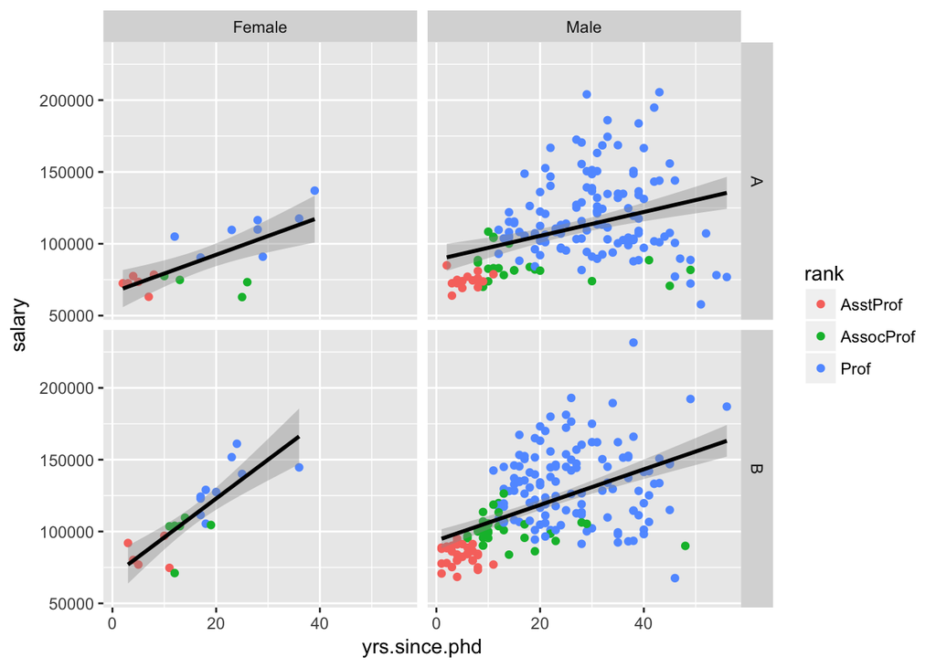

```r
faceting <- ggplot(data=Salaries, aes(x=yrs.since.phd, y=salary)) +
          geom_point(aes(color=rank)) +
          geom_smooth(method="lm", color="black") +
          # here's a facet_grid component instead
          facet_grid(discipline~sex)
print(faceting)
```

You can add the argument `scales="free"` to ether facet function to remove the imposition of shared scales:

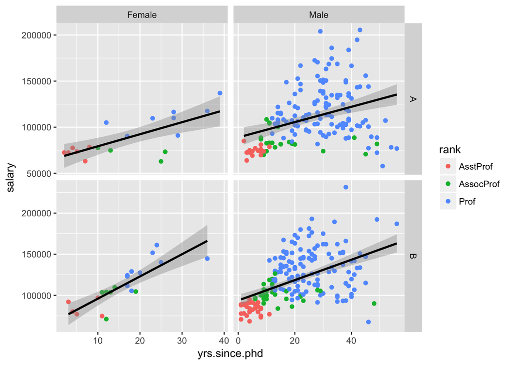

```r
faceting <- ggplot(data=Salaries, aes(x=yrs.since.phd, y=salary)) +
          geom_point(aes(color=rank)) +
          geom_smooth(method="lm", color="black") +
          facet_grid(discipline~sex, scales="free")
print(faceting)
```

### Labels

The default labels that come with this plot aren’t the most clear– there’s no title, and my axis labels are just my column names, which aren’t super readable. I can change all three of those things with the `labs()` function:

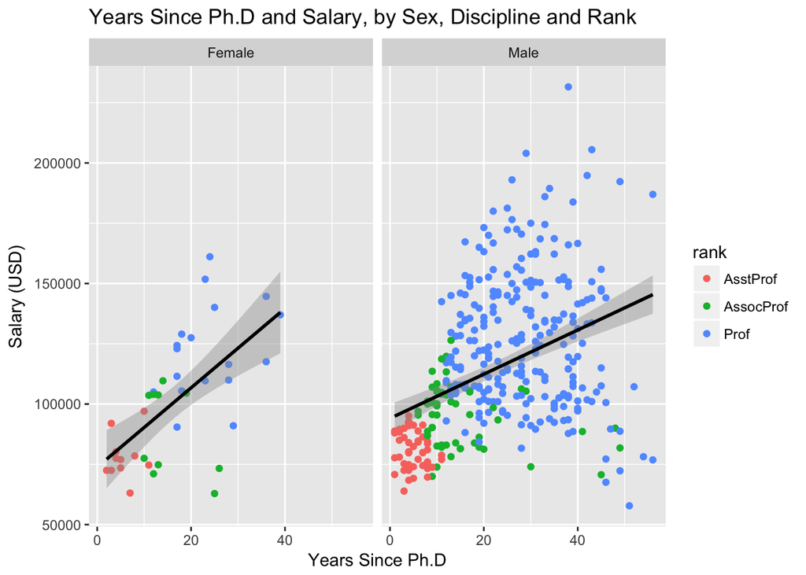

```r
labels <- ggplot(data=Salaries, aes(x=yrs.since.phd, y=salary)) +
          geom_point(aes(color=rank)) +
          geom_smooth(method="lm", color="black") +
          facet_wrap(~sex)+
          # adding labels
          labs(title="Years Since Ph.D and Salary, by Sex, Discipline and Rank",
               x="Years Since Ph.D",
               y="Salary (USD)")
print(labels)
```

And that there is a clean, attractive, layered, faceted, mapped, and labeled ggplot object! We’ve made a nice plot, and explored how each component of it is *modular*, *removable*, and *customizeable*.

In this example I’ve just explored one geom type: `geom_point`. But there are literally dozens of others! Play around with them yourself, try starting with a simple plot and building up to a complex one. the [ggplot cheat sheet](https://www.rstudio.com/wp-content/uploads/2015/03/ggplot2-cheatsheet.pdf) and the [R for Data Science chapter on `ggplot`](http://r4ds.had.co.nz/data-visualisation.html) will both help you, especially with tricky geoms like `geom_bar`.

## Examples of Common `ggplot` Geoms

I haven’t included labels/titles in these to make them as simple as possible. Also see the `ggplot` cheat sheet for many more details.

### Bar Plots & Relatives

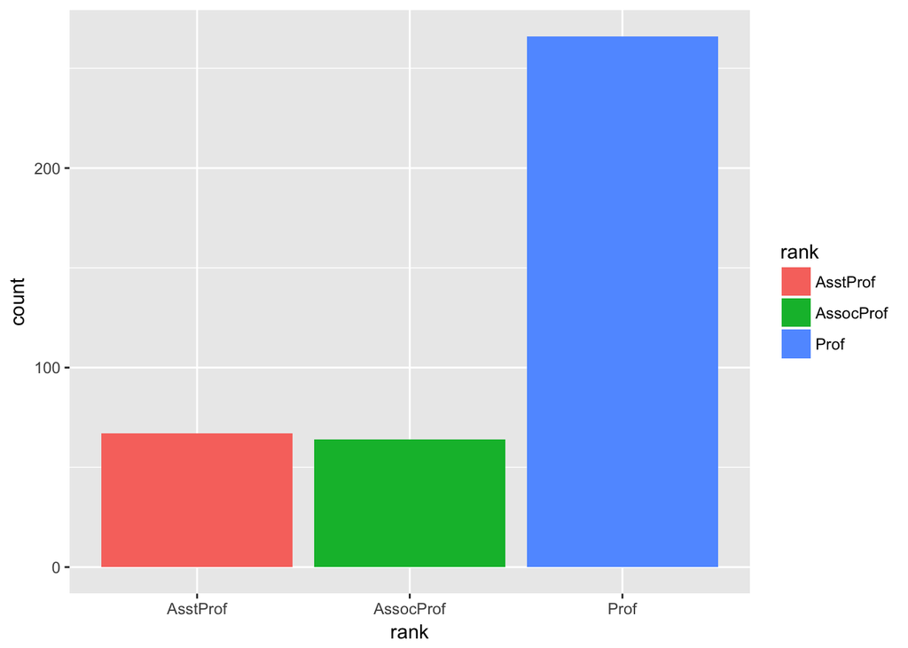

```r
## Notice two things about this code.
## First of all, I use the `fill` argument to `aes` instead of `color`,
## because I want to *fill* in the bar. Using the `color` argument will only color the outline of the bar.

## Secondly, I don't specify a "y" aesthetic.
## By default, `geom_bar` makes a histogram, which counts how many rows there are in each element
## and plots that as the "y" value.
ggplot(Salaries, aes(x=rank)) +
  geom_bar(aes(fill=rank))
```

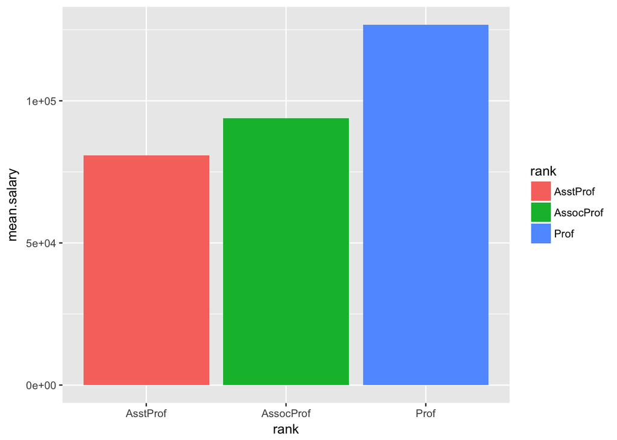

```r
## Here I want a bar plot with a `y` compoent that I specify: the mean salary, by rank.
## I do this by adding a `y` aesthetic, but I also have to change the `stat` argument in `geom_bar`
## so it knows to expect that `y` argument.

## Notice also that I *aggregate* my dataset down to mean values in order to make this plot make sense.
## What would happen if I ran this code on the entire dataset?
ggplot(Salaries[, list(mean.salary=mean(salary)), by=list(rank)], aes(x=rank, y=mean.salary))+
  geom_bar(aes(fill=rank), stat="identity")
```

### Line plots

There isn’t a natural use for a line plot in the data as it stands, because we’re not tracking individuals over time (or any other variable)– our data is *cross-sectional*. To prove it to you, here’s what happens if I try to make a line plot with the data as it stands:

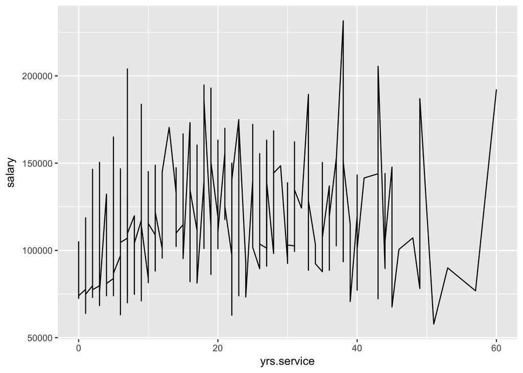

```r
ggplot(Salaries, aes(x=yrs.service, y=salary)) +
  geom_line()
```

Yikes, what a mess! It would be better to take the *mean value* across our x-value first:

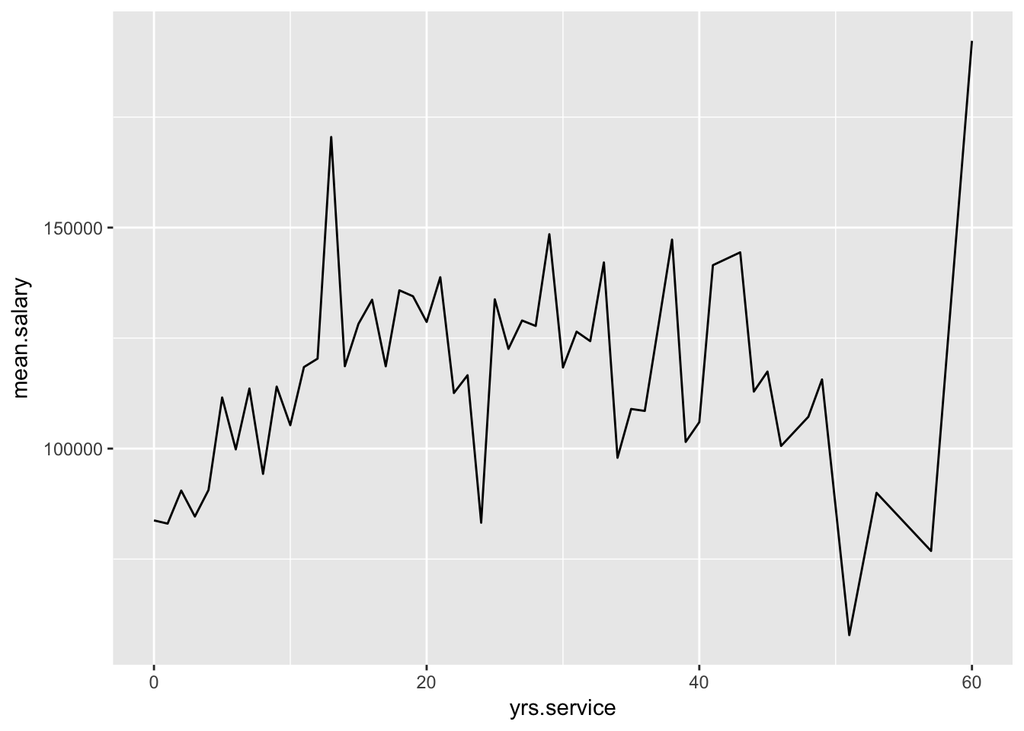

```r
mean_salary_by_service <- Salaries[, list(mean.salary=mean(salary)), by=list(yrs.service)]
ggplot(mean_salary_by_service, aes(x=yrs.service, y=mean.salary))+
  geom_line()
```

That’s better! It would be nice to include a scatter plot of the original data behind it, so we can see what data we’re taking the mean of. This involves attaching a different dataset and different aesthetics to each geom:

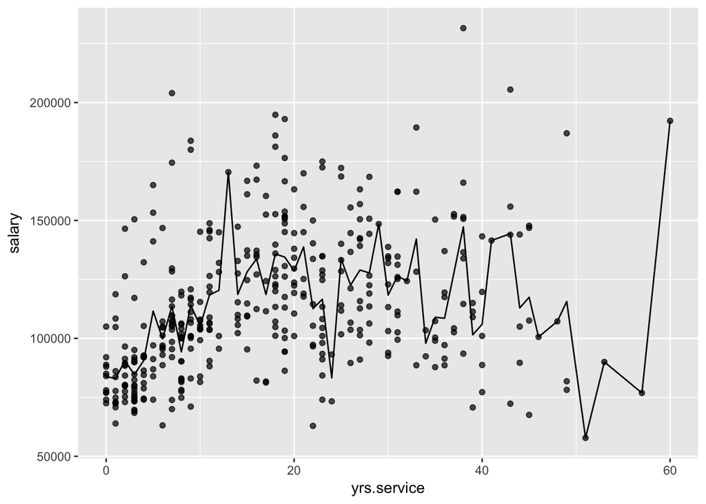

```r
ggplot() +
  ## The 'alpha' argument denotes *transparency*: 1 is fully dark, 0 is invisible
  geom_point(data=Salaries, aes(y=salary, x=yrs.service), alpha=0.7)+
  geom_line(data=mean_salary_by_service, aes(y=mean.salary, x=yrs.service))
```

Notice how different my plotting code looks here. My `ggplot` object is completely empty, and I have a different `data` argument and different `aes` components for each `geom`. In general, the `ggplot` functions should contain whatever arguments and aesthetics you want to apply to the *entire* dataset, and the `geom` functions should contain only those things that apply to a single `geom` specifically.

### Density Plot

Density plots are kind of like smooth histograms– they show you the *distribution* of a single value in your dataset.

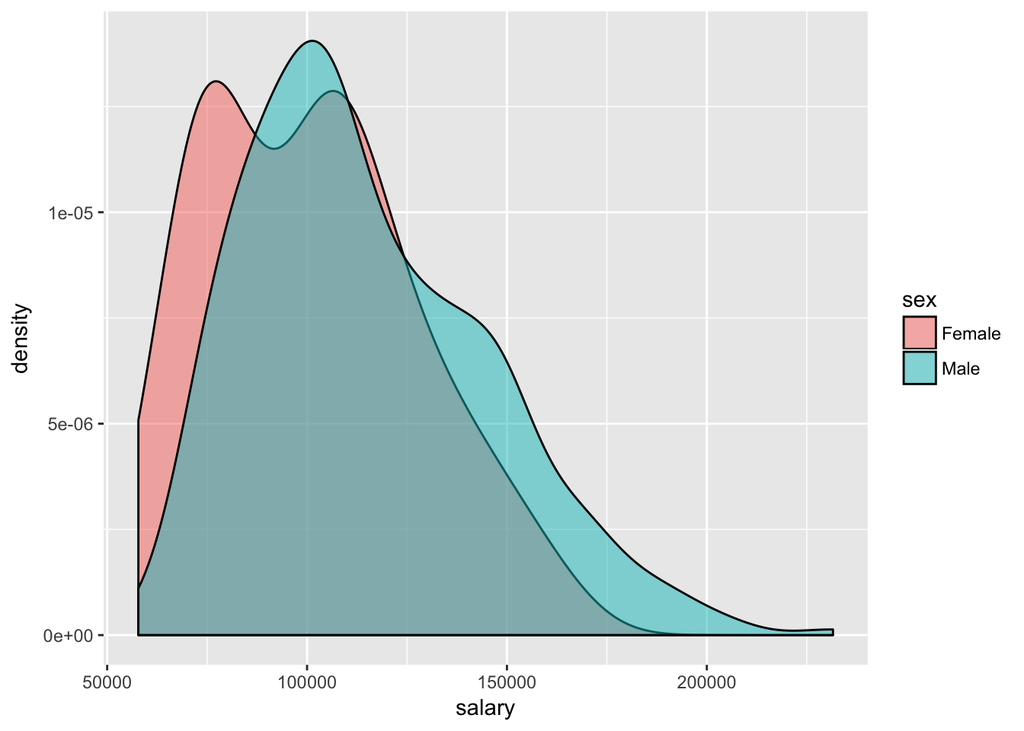

```r
ggplot(Salaries, aes(x=salary)) +
  # notice the use of both "fill" and "alpha" here:
  geom_density(aes(fill=sex), alpha=0.5)
```

## Reshaping and `ggplot`

Why did I spend all that time last lecture telling you about reshaping? When is it useful? Well, let’s take a look back at that cereal dataset:

```r
# load MASS library and UScereal dataset
library(MASS)
data(UScereal)

# save the names of cereals as an actual row, instead of an index value
UScereal$cereal_name <- rownames(UScereal)

# convert to a data.table
UScereal <- data.table(UScereal)

# clean up some column values
UScereal[, shelf:=NULL] # we won't need that column
UScereal[, sodium:= sodium/1000] # this converts the units of the "sodium" column from milligrams to grams

# rearrange the column order
setcolorder(UScereal, c("cereal_name", "mfr", "vitamins", "calories", "protein", "fat", "sodium", "fibre", "carbo", "sugars", "potassium"))
```

```r
print(head(UScereal))
```

```
##                  cereal_name mfr vitamins calories   protein      fat
## 1:                 100% Bran   N enriched 212.1212 12.121212 3.030303
## 2:                  All-Bran   K enriched 212.1212 12.121212 3.030303
## 3: All-Bran with Extra Fiber   K enriched 100.0000  8.000000 0.000000
## 4:   Apple Cinnamon Cheerios   G enriched 146.6667  2.666667 2.666667
## 5:               Apple Jacks   K enriched 110.0000  2.000000 0.000000
## 6:                   Basic 4   G enriched 173.3333  4.000000 2.666667
##       sodium     fibre    carbo   sugars potassium
## 1: 0.3939394 30.303030 15.15152 18.18182 848.48485
## 2: 0.7878788 27.272727 21.21212 15.15151 969.69697
## 3: 0.2800000 28.000000 16.00000  0.00000 660.00000
## 4: 0.2400000  2.000000 14.00000 13.33333  93.33333
## 5: 0.1250000  1.000000 11.00000 14.00000  30.00000
## 6: 0.2800000  2.666667 24.00000 10.66667 133.33333
```

Let’s say I want to make a density plot for each of the numeric column values, colored by vitamin type. I could write eight different plots, or I could write a loop that creates plots, but it would be great if there were some way to plot all of them all at once.

`facet_wrap` seems like an obvious choice, but I can’t use it with the dataset as it stands. `facet_wrap` only works when there’s one column that has *the names of the categories I want to facet on* and one column that has *the values of those categories*. Why does that data structure sound familiar…?

Let’s see how we can easily make this plot:

```r
# melt all numeric columns of the dataset
melted_UScereal <- melt(UScereal, id.vars=c("cereal_name", "mfr", "vitamins"))

print(head(melted_UScereal))
```

```
##                  cereal_name mfr vitamins variable    value
## 1:                 100% Bran   N enriched calories 212.1212
## 2:                  All-Bran   K enriched calories 212.1212
## 3: All-Bran with Extra Fiber   K enriched calories 100.0000
## 4:   Apple Cinnamon Cheerios   G enriched calories 146.6667
## 5:               Apple Jacks   K enriched calories 110.0000
## 6:                   Basic 4   G enriched calories 173.3333
```

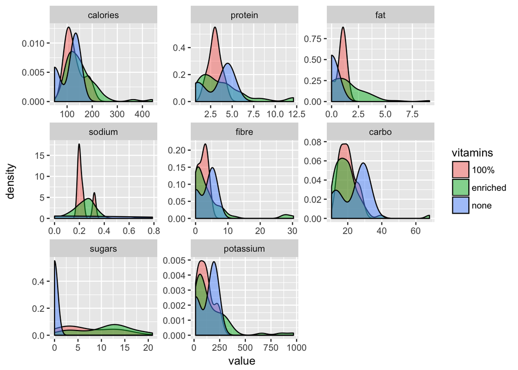

```r
# plot this melted dataset, faceting on the "variable" column
ggplot(melted_UScereal, aes(x=value)) +
  geom_density(aes(fill=vitamins), alpha=0.5)+
  facet_wrap(~variable, scales="free")
```

So much better than a loop, or eight completely individual plots! Reshaping is incredibly useful for plotting.

This is a lot of information, and `ggplot` takes some getting used to, but it’s just about the best plotting library I’ve found in any programming language. I encourage you to practice on your own and see what you can come up with– the [ggplot cheat sheet](https://www.rstudio.com/wp-content/uploads/2015/03/ggplot2-cheatsheet.pdf), [Wickham’s `ggplot` chapter in “R for Data Science”](http://r4ds.had.co.nz/data-visualisation.html), and the Internet’s forums are all there to help you when you get stuck.

[^1]: Much much more on these next module.